# Coding Lab: Reading Files, Data Frames and Calculations

10/8/2019

## Lecture outline

- packages and `tidyverse`
- reading data files into R
- detour: directory structures
- manipulating data with `dplyr`
- detour: manipulating data with `baseR`
- workshop

## what are packages?

‘packages’ extend the capabilities of R, so we don’t have to start from scratch.

In practice, a package makes a new set of functions available to you.

`tidyverse` is a set of packages that drastically improve R’s usability.

```
Analogy:
- base R comes with a screw driver and hand saw.
- `tidyverse` gives you power tools
```

## installing and loading packages

To use a package we need to:

- install it once from the internet

```r
install.packages("readxl")
```

- load it *each time* we restart R

```r
library(readxl)
read_xlsx("some_data.xls")
```

- `package::command()` lets you call a function without loading the library

```r
readxl::read_xlsx("some_data.xls")
```

## common package error

The package ‘haven’ provides a function to read dta files called `read_dta()`. What goes wrong here?

```r
install.packages("haven")
our_data <- read_dta("my_file.dta")
```

Error in read_dta(“my_file.dta”) : could not find function “read_dta”

## common package error

We need to load the package using `library()`!

```r
library(haven)
our_data <- read_dta("my_file.dta")
```

## `tidyverse`: set of useful packages

Think of the `tidyverse` packages providing a new dialect for R.

```r
library(tidyverse)
```

```
── Attaching packages ──
───── tidyverse 1.2.1 ──
✔ ggplot2 3.1.0     ✔ purrr   0.3.0
✔ tibble  2.0.1     ✔ dplyr   0.8.3
✔ tidyr   0.8.2     ✔ stringr 1.3.1
✔ readr   1.3.1     ✔ forcats 0.3.0
── Conflicts ──────────
──── tidyverse_conflicts() ──
✖ dplyr::filter() masks stats::filter()
✖ dplyr::lag()    masks stats::lag()
```

## loading data

We can load data into R with different functions depending on the data format.

```r
texas_housing_data <- read_csv("texas_housing_data.csv")
# disclaimer: not a real dataset
```

| file type | package | function |
| --- | --- | --- |
| csv | readr | `read_csv()` |
| dta (stata) | haven | `read_dta()` |
| xlsx | readxl | `read_xlsx()` |

Note: `readr` is loaded with `tidyverse`

## looking at data

We can see what the data looks like:

```r
texas_housing_data <- get("txhousing") # txhousing is in tidyverse

head(texas_housing_data)
```

```
## # A tibble: 6 x 9
##   city     year month sales   volume median listings inventory  date
##   <chr>   <int> <int> <dbl>    <dbl>  <dbl>    <dbl>     <dbl> <dbl>
## 1 Abilene  2000     1    72  5380000  71400      701       6.3 2000
## 2 Abilene  2000     2    98  6505000  58700      746       6.6 2000.
## 3 Abilene  2000     3   130  9285000  58100      784       6.8 2000.
## 4 Abilene  2000     4    98  9730000  68600      785       6.9 2000.
## 5 Abilene  2000     5   141 10590000  67300      794       6.8 2000.
## 6 Abilene  2000     6   156 13910000  66900      780       6.6 2000.
```

## detour: directory structure

Computer hard drives are organized using a **file system**. In this way, each file has a unique “address”.

```
- `~/Downloads/some_data.csv`
- `~/Documents/teaching/coding_lab/presentations/workshop_2.html`
```

## detour: directory structure

The files are stored in folders or directories which are analagous to “zip codes”.

```
- `~/Downloads/`
- `~/Documents/teaching/coding_lab/presentations/`
```

In Windows, the directory usually look slighly different (e.g. `C://...`)

## detour: directory structure

The ‘working directory’ in an R session is the directory your script knows about. If the data you want is in that directory you can refer to it directly.

```r
fed_data <- read_xlsx("SCE-Public-LM-Quarterly-Microdata.xlsx")
```

Hint: `getwd()` shows your current working directory .

## detour: directory structure

if the data were not in your current working directory you could:

- give the full address: `read_csv("~/Documents/stat1/data/file.csv")`
- give a relative address: `read_csv("data/file.csv")`
- move the file to the current working directory: `drag and drop`
- change the current working directory: `setwd("~/Documents/stat1/data")`

## loading data?

While often you can just load the data directly, we often require finesse

```r
fed_data <-
  read_xlsx("../data/SCE-Public-LM-Quarterly-Microdata.xlsx")
head(fed_data)
```

```
## # A tibble: 6 x 1
##   `License for Survey of Consumer Expectations Data and Questions`
##   <chr>
## 1 <NA>
## 2 The Survey of Consumer Expectations (the “SCE”) was developed and is own…
## 3 FRBNY launched the SCE in 2013.  The subject matter and wording of indiv…
## 4 questions have been informed by or adapted from other public surveys.
## 5 FRBNY has published the SCE questions and most data it collects through …
## 6 and resuse. FRBNY permits use of the SCE questions and FRBNY-published S…
```

```r
fed_data <-
  read_xlsx("../data/SCE-Public-LM-Quarterly-Microdata.xlsx",
            sheet = "Data 2013",
            skip = 1)
head(fed_data)
```

```
## # A tibble: 6 x 488
##   userid weight L1_rc L2_rc    L4    L5   L5b    L6   L6b   L6c    L7    L8
##    <dbl>  <dbl> <dbl> <dbl> <dbl> <dbl> <dbl> <dbl> <dbl> <dbl> <dbl> <dbl>
## 1 7.00e7  0.662     2     1     0    NA    NA     2    NA    NA  3600    NA
## 2 7.00e7  0.738     1     1     0    NA    NA     3     2     3    NA    NA
## 3 7.00e7  0.473     1     3     0    NA    NA     2    NA    NA    14    NA
## 4 7.00e7  4.62      9    NA    NA     0     2    NA    NA    NA    NA    70
## 5 7.00e7  0.491     2     1     1    NA    NA    NA    NA    NA    NA    NA
## 6 7.00e7  0.348     1     3     0    NA    NA     1    NA    NA  1080    NA
## # … with 476 more variables: L9 <dbl>, L10 <dbl>, L11_hourly <dbl>,
## #   L11_weekly <dbl>, L11_annual <dbl>, L11_flag <dbl>, JH9_hourly <dbl>,
## #   JH9_weekly <dbl>, JH9_annual <dbl>, L14self_1_rc <dbl>,
## #   L14self_2_rc <dbl>, L14self_3_rc <dbl>, L14self_4_rc <dbl>,
## #   L14_1_rc <dbl>, L14_2_rc <dbl>, L14_3_rc <dbl>, L14_4_rc <dbl>,
## #   L14_5_rc <dbl>, L14_6_rc <dbl>, L14_7_rc <dbl>, L14_8_rc <dbl>,
## #   L14_9_rc <dbl>, L14_11_rc <dbl>, L14_12_rc <dbl>, L14_13_rc <dbl>,
## #   L18_1_rc <dbl>, L18_2_rc <dbl>, L18_3_rc <dbl>, L18_4_rc <dbl>,
## #   L18_5_rc <dbl>, L18_6_rc <dbl>, L18_7_rc <dbl>, L18_8_rc <dbl>,
## #   L18_9_rc <dbl>, L18_11_rc <dbl>, L18_12_rc <dbl>, L18_13_rc <dbl>,
## #   L20 <dbl>, L21 <dbl>, L22 <dbl>, L24_hourly <dbl>, L24_weekly <dbl>,
## #   L24_annual <dbl>, L24_flag <dbl>, L25self <dbl>, L25_1_rc <dbl>,
## #   L25_2_rc <dbl>, L25_3_rc <dbl>, L25_4_rc <dbl>, L25_5_rc <dbl>,
## #   L25_6_rc <dbl>, L25_7_rc <dbl>, L25_8_rc <dbl>, L25_9_rc <dbl>,
## #   L25_11_rc <dbl>, L25_12_rc <dbl>, L25_13_rc <dbl>, EC1a_rc <dbl>,
## #   EC1b_rc <dbl>, EC1f_rc <dbl>, EC2a <dbl>, EC3a <dbl>, EC3b <dbl>,
## #   EC3c <dbl>, EC5 <dbl>, EC6_rc <dbl>, EC7a <dbl>, EC7b <dbl>,
## #   EC8a <dbl>, EC8b <dbl>, ES1_1_rc <dbl>, ES1_2_rc <dbl>,
## #   ES1_3_rc <dbl>, ES1a <dbl>, ES3a_rc <dbl>, ES3b <dbl>, ES4 <dbl>,
## #   ES5new <dbl>, ES6 <dbl>, ES7_1_rc <dbl>, ES7_2_rc <dbl>,
## #   ES7_3_rc <dbl>, ES7_4_rc <dbl>, ES7_5_rc <dbl>, ES7_6_rc <dbl>,
## #   ES7_7_rc <dbl>, ES7_8_rc <dbl>, ES7_9_rc <dbl>, ES7_11_rc <dbl>,
## #   ES7_12_rc <dbl>, ES7_13_rc <dbl>, ES9 <dbl>, ES11 <dbl>, ES12 <dbl>,
## #   EO1 <dbl>, EO2 <dbl>, EO3 <dbl>, EO3anew <dbl>, EO4_rc <dbl>,
## #   EO5 <dbl>, …
```

## looking at data: `head()`, `glimpse()` or `View()`

- `head()` and `glimpse()` provide ways to see part of your data.
- `View()` provides a more spreadsheet-like experience.

## getting meta data

Get number of rows and columns

```r
dim(fed_data)
```

```
## [1] 1333  488
```

See column names

```r
names(fed_data)
```

```
##   [1] "userid"                "weight"
##   [3] "L1_rc"                 "L2_rc"
##   [5] "L4"                    "L5"
##   [7] "L5b"                   "L6"
##   [9] "L6b"                   "L6c"
##  [11] "L7"                    "L8"
##  [13] "L9"                    "L10"
##  [15] "L11_hourly"            "L11_weekly"
##  [17] "L11_annual"            "L11_flag"
##  [19] "JH9_hourly"            "JH9_weekly"
##  [21] "JH9_annual"            "L14self_1_rc"
##  [23] "L14self_2_rc"          "L14self_3_rc"
##  [25] "L14self_4_rc"          "L14_1_rc"
##  [27] "L14_2_rc"              "L14_3_rc"
##  [29] "L14_4_rc"              "L14_5_rc"
```

[output cut: 229 more lines]

## data manipulation with `dplyr`

## selecting columns with `select()`

[figure not shown]

## selecting columns with `select()`

Use case: You want to present a subset of your columns

```r
select(texas_housing_data, city, date, sales, listings)
```

```
## # A tibble: 8,602 x 4
##    city     date sales listings
##    <chr>   <dbl> <dbl>    <dbl>
##  1 Abilene 2000     72      701
##  2 Abilene 2000.    98      746
##  3 Abilene 2000.   130      784
##  4 Abilene 2000.    98      785
##  5 Abilene 2000.   141      794
##  6 Abilene 2000.   156      780
##  7 Abilene 2000.   152      742
##  8 Abilene 2001.   131      765
##  9 Abilene 2001.   104      771
## 10 Abilene 2001.   101      764
## # … with 8,592 more rows
```

## selecting columns with `select()`

Use case: You want to present a subset of your columns

```r
select(texas_housing_data, -c(city, date, sales, listings))
```

```
## # A tibble: 8,602 x 5
##     year month   volume median inventory
##    <int> <int>    <dbl>  <dbl>     <dbl>
##  1  2000     1  5380000  71400       6.3
##  2  2000     2  6505000  58700       6.6
##  3  2000     3  9285000  58100       6.8
##  4  2000     4  9730000  68600       6.9
##  5  2000     5 10590000  67300       6.8
##  6  2000     6 13910000  66900       6.6
##  7  2000     7 12635000  73500       6.2
##  8  2000     8 10710000  75000       6.4
##  9  2000     9  7615000  64500       6.5
## 10  2000    10  7040000  59300       6.6
## # … with 8,592 more rows
```

## selecting columns with `select()`

Use case: You want to present a subset of your columns

```r
select(texas_housing_data, -c(city, date, sales, listings))
```

The `-` says to exclude the columns listed in the vector.

## selecting columns with `select()`, helpers

Use case: You want to reorder your columns

```r
select(texas_housing_data, city, date, sales, listings, everything())
```

```
## # A tibble: 8,602 x 9
##    city     date sales listings  year month   volume median inventory
##    <chr>   <dbl> <dbl>    <dbl> <int> <int>    <dbl>  <dbl>     <dbl>
##  1 Abilene 2000     72      701  2000     1  5380000  71400       6.3
##  2 Abilene 2000.    98      746  2000     2  6505000  58700       6.6
##  3 Abilene 2000.   130      784  2000     3  9285000  58100       6.8
##  4 Abilene 2000.    98      785  2000     4  9730000  68600       6.9
##  5 Abilene 2000.   141      794  2000     5 10590000  67300       6.8
##  6 Abilene 2000.   156      780  2000     6 13910000  66900       6.6
##  7 Abilene 2000.   152      742  2000     7 12635000  73500       6.2
##  8 Abilene 2001.   131      765  2000     8 10710000  75000       6.4
##  9 Abilene 2001.   104      771  2000     9  7615000  64500       6.5
## 10 Abilene 2001.   101      764  2000    10  7040000  59300       6.6
## # … with 8,592 more rows
```

## selecting columns with `select()`, helpers

Use case: You have a lot of columns and you want it to be easier to work with your data

```r
dim(fed_data)
```

```
## [1] 1333  488
```

```r
# say you're only interested in question L18.
slim_fed_data <- select(fed_data, userid, weight, starts_with("L18"))
dim(slim_fed_data)
```

```
## [1] 1333   15
```

## selecting columns with `select()`

```r
# say you're only interested in question L18.
names(slim_fed_data)
```

```
##  [1] "userid"          "weight"          "L18_1_rc"
##  [4] "L18_2_rc"        "L18_3_rc"        "L18_4_rc"
##  [7] "L18_5_rc"        "L18_6_rc"        "L18_7_rc"
## [10] "L18_8_rc"        "L18_9_rc"        "L18_11_rc"
## [13] "L18_12_rc"       "L18_13_rc"       "L18_impute_flag"
```

Notice we used a “select_helpers” function `starts_with()`. There are several useful functions like this.

(For more information see r4ds chapter 5.4)

## creating columns with `mutate()`

[figure not shown]

## creating columns with `mutate()`

Use case: you want to create a new column of data

```r
mutate(texas_housing_data, mean_house_price = volume / sales)
```

```
## # A tibble: 8,602 x 10
##    city   year month sales volume median listings inventory  date
##    <chr> <int> <int> <dbl>  <dbl>  <dbl>    <dbl>     <dbl> <dbl>
##  1 Abil…  2000     1    72 5.38e6  71400      701       6.3 2000
##  2 Abil…  2000     2    98 6.50e6  58700      746       6.6 2000.
##  3 Abil…  2000     3   130 9.28e6  58100      784       6.8 2000.
##  4 Abil…  2000     4    98 9.73e6  68600      785       6.9 2000.
##  5 Abil…  2000     5   141 1.06e7  67300      794       6.8 2000.
##  6 Abil…  2000     6   156 1.39e7  66900      780       6.6 2000.
##  7 Abil…  2000     7   152 1.26e7  73500      742       6.2 2000.
##  8 Abil…  2000     8   131 1.07e7  75000      765       6.4 2001.
##  9 Abil…  2000     9   104 7.62e6  64500      771       6.5 2001.
## 10 Abil…  2000    10   101 7.04e6  59300      764       6.6 2001.
## # … with 8,592 more rows, and 1 more variable: mean_house_price <dbl>
```

Oops, we can’t see our work!

## We couldn’t see the result!

One approach:

- Store `mutate()` step as intermediate data.
- Then use `select()`

```r
texas_housing_data_w_mean <-
  mutate(texas_housing_data, mean_house_price = volume / sales)

select(texas_housing_data_w_mean,
       city, date, mean_house_price, median)
```

```
## # A tibble: 8,602 x 4
##    city     date mean_house_price median
##    <chr>   <dbl>            <dbl>  <dbl>
##  1 Abilene 2000            74722.  71400
##  2 Abilene 2000.           66378.  58700
##  3 Abilene 2000.           71423.  58100
##  4 Abilene 2000.           99286.  68600
##  5 Abilene 2000.           75106.  67300
##  6 Abilene 2000.           89167.  66900
##  7 Abilene 2000.           83125   73500
##  8 Abilene 2001.           81756.  75000
##  9 Abilene 2001.           73221.  64500
## 10 Abilene 2001.           69703.  59300
## # … with 8,592 more rows
```

## We couldn’t see the result!

One approach:

- Store `mutate()` step as intermediate data.
- Then use `select()`

```r
texas_housing_data_w_mean <-
  mutate(texas_housing_data, mean_house_price = volume / sales)

select(texas_housing_data_w_mean, city, date, mean_house_price, median)
```

Downsides:

- extra names to invent and remember
- code is cluttered and hard to read

## Ceci est une `%>%`

The pipe `%>%` operator takes the left-hand side and makes it *input* in the right-hand side.

- by default, the left-hand side is the *first argument* of the right-hand side function.

```r
# a tibble is the first argument
select(texas_housing_data, city, year, sales, volume)

texas_housing_data %>%
  select(city, year, sales, volume)
```

## Ceci est une `%>%`

We can chain together tidyverse functions to avoid making so many intermediate data frames!

```r
texas_housing_data %>%
  mutate(mean_house_price = volume / sales) %>%
  select(city, date, mean_house_price, median)
```

```
## # A tibble: 8,602 x 4
##    city     date mean_house_price median
##    <chr>   <dbl>            <dbl>  <dbl>
##  1 Abilene 2000            74722.  71400
##  2 Abilene 2000.           66378.  58700
##  3 Abilene 2000.           71423.  58100
##  4 Abilene 2000.           99286.  68600
##  5 Abilene 2000.           75106.  67300
##  6 Abilene 2000.           89167.  66900
##  7 Abilene 2000.           83125   73500
##  8 Abilene 2001.           81756.  75000
##  9 Abilene 2001.           73221.  64500
## 10 Abilene 2001.           69703.  59300
## # … with 8,592 more rows
```

## creating columns with `mutate()`

Under the hood, each column is a vector.

Underlying mutate is a vectorized computation.

```r
mutant_data <- texas_housing_data %>%
  mutate(mean_house_price = volume / sales,
         difference = mean_house_price - median)
```

## How have Texas housing prices changed over time?

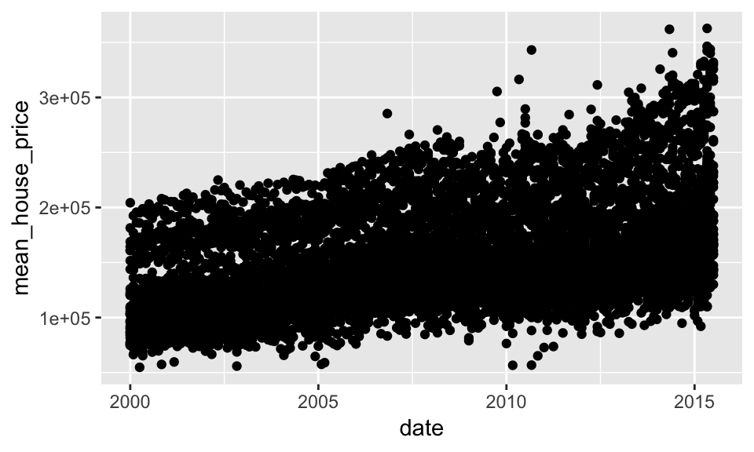

```r
mutant_data %>%
  ggplot(aes(x = date, y = mean_house_price)) + geom_point()
```

## summarizing data with `summarize()`

[figure not shown]

## summarizing data with `summarize()`

Use case: We want summary statistics of the data.

```r
summary_data <-
texas_housing_data %>%
  summarize(total_sales = sum(sales, na.rm = TRUE),
            total_volume = sum(volume, na.rm = TRUE),
            mean_house_price = total_volume / total_sales)
```

## summarizing data with `summarize()`

```r
summary_data
```

```
## # A tibble: 1 x 3
##   total_sales total_volume mean_house_price
##         <dbl>        <dbl>            <dbl>
## 1     4415202 858502159353          194442.
```

## grouped summary with `group_by()` + `summarize()`

[figure not shown]

## grouped summary with `group_by()` + `summarize()`

Use case: You want summary statistics for certain subsets of the data.

```r
annual_housing_prices <- texas_housing_data %>%
  group_by(year) %>%
  summarize(total_sales = sum(sales, na.rm = TRUE),
            total_volume = sum(volume, na.rm = TRUE),
            mean_house_price = total_volume / total_sales)
```

## How have Texas housing prices changed over time?

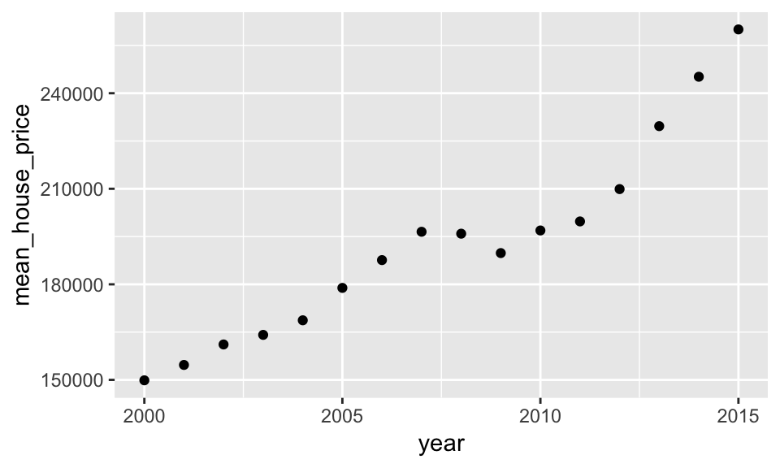

```r
annual_housing_prices %>%
  ggplot(aes(x = year, y = mean_house_price)) + geom_point()
```

## grouped summary with `group_by()` + `summarize()`

Use case: You want summary statistics for certain subsets of the data.

```r
texas_housing_data %>%
  group_by(city, year) %>%
  summarize(total_sales = sum(sales, na.rm = TRUE),
            total_volume = sum(volume, na.rm = TRUE),
            mean_house_price = total_volume / total_sales)
```

```
## # A tibble: 736 x 5
## # Groups:   city [46]
##    city     year total_sales total_volume mean_house_price
##    <chr>   <int>       <dbl>        <dbl>            <dbl>
##  1 Abilene  2000        1375    108575000           78964.
##  2 Abilene  2001        1431    114365000           79920.
##  3 Abilene  2002        1516    118675000           78282.
##  4 Abilene  2003        1632    135675000           83134.
##  5 Abilene  2004        1830    159670000           87251.
##  6 Abilene  2005        1977    198855000          100584.
##  7 Abilene  2006        1997    227530000          113936.
##  8 Abilene  2007        2003    232062585          115858.
##  9 Abilene  2008        1651    192520335          116608.
## 10 Abilene  2009        1634    202357756          123842.
## # … with 726 more rows
```

## How have Texas housing prices changed over time in certain cities?

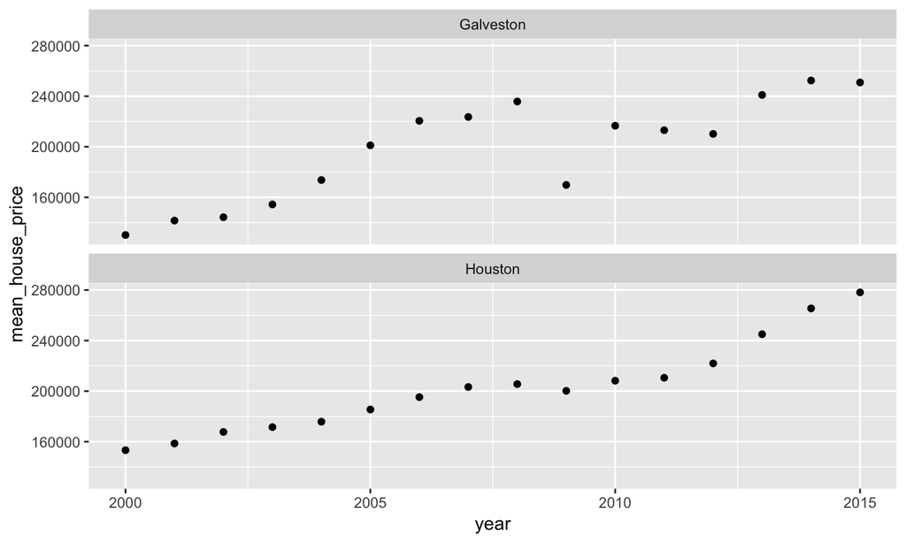

## two more dplyr functions you’ll see in the workshop

## sort rows with `arrange()`

[figure not shown]

```r
texas_housing_data %>%
  arrange(year)
```

```
## # A tibble: 8,602 x 9
##    city     year month sales   volume median listings inventory  date
##    <chr>   <int> <int> <dbl>    <dbl>  <dbl>    <dbl>     <dbl> <dbl>
##  1 Abilene  2000     1    72  5380000  71400      701       6.3 2000
##  2 Abilene  2000     2    98  6505000  58700      746       6.6 2000.
##  3 Abilene  2000     3   130  9285000  58100      784       6.8 2000.
##  4 Abilene  2000     4    98  9730000  68600      785       6.9 2000.
##  5 Abilene  2000     5   141 10590000  67300      794       6.8 2000.
##  6 Abilene  2000     6   156 13910000  66900      780       6.6 2000.
##  7 Abilene  2000     7   152 12635000  73500      742       6.2 2000.
##  8 Abilene  2000     8   131 10710000  75000      765       6.4 2001.
##  9 Abilene  2000     9   104  7615000  64500      771       6.5 2001.
## 10 Abilene  2000    10   101  7040000  59300      764       6.6 2001.
## # … with 8,592 more rows
```

```r
texas_housing_data %>%
  arrange(desc(year))
```

```
## # A tibble: 8,602 x 9
##    city      year month sales   volume median listings inventory  date
##    <chr>    <int> <int> <dbl>    <dbl>  <dbl>    <dbl>     <dbl> <dbl>
##  1 Abilene   2015     1   158 23486998 134100      801       4.4 2015
##  2 Abilene   2015     2   151 19834263 126500      767       4.1 2015.
##  3 Abilene   2015     3   198 31869437 136800      821       4.4 2015.
##  4 Abilene   2015     4   201 28301159 129600      891       4.7 2015.
##  5 Abilene   2015     5   199 31385757 144700      919       4.8 2015.
##  6 Abilene   2015     6   260 41396230 141500      965       5   2015.
##  7 Abilene   2015     7   268 45845730 148700      986       5   2016.
##  8 Amarillo  2015     1   204 33188726 138500     1120       4.3 2015
##  9 Amarillo  2015     2   188 34355428 149400     1084       4.2 2015.
## 10 Amarillo  2015     3   317 53603130 140900     1051       3.9 2015.
## # … with 8,592 more rows
```

## choose rows of interest with `filter()`

[figure not shown]

```r
texas_housing_data %>%
  filter(year == 2013)
```

```
## # A tibble: 552 x 9
##    city     year month sales   volume median listings inventory  date
##    <chr>   <int> <int> <dbl>    <dbl>  <dbl>    <dbl>     <dbl> <dbl>
##  1 Abilene  2013     1   114 15794494 125300      966       5.7 2013
##  2 Abilene  2013     2   140 16552641  94400      943       5.6 2013.
##  3 Abilene  2013     3   164 19609711 102500      958       5.7 2013.
##  4 Abilene  2013     4   213 27261796 113700      948       5.5 2013.
##  5 Abilene  2013     5   225 31901380 130000      923       5.3 2013.
##  6 Abilene  2013     6   209 29454125 127300      960       5.5 2013.
##  7 Abilene  2013     7   218 32547446 140000      969       5.4 2014.
##  8 Abilene  2013     8   236 30777727 120000      976       5.4 2014.
##  9 Abilene  2013     9   195 26237106 127500      985       5.4 2014.
## 10 Abilene  2013    10   167 21781187 119000      993       5.5 2014.
## # … with 542 more rows
```

```r
texas_housing_data %>%
  filter(year == 2013, city == "Houston")
```

```
## # A tibble: 12 x 9
##    city     year month sales     volume median listings inventory  date
##    <chr>   <int> <int> <dbl>      <dbl>  <dbl>    <dbl>     <dbl> <dbl>
##  1 Houston  2013     1  4273  852045057 149500    21364       3.7 2013
##  2 Houston  2013     2  4886 1060985674 161900    21293       3.6 2013.
##  3 Houston  2013     3  6382 1479273481 172300    20909       3.5 2013.
##  4 Houston  2013     4  7116 1770746764 182400    20607       3.4 2013.
##  5 Houston  2013     5  8439 2121508529 186100    20526       3.3 2013.
##  6 Houston  2013     6  7935 2073909387 191600    21008       3.3 2013.
##  7 Houston  2013     7  8468 2168720825 187800    21497       3.3 2014.
##  8 Houston  2013     8  8155 2083377894 186700    21366       3.3 2014.
##  9 Houston  2013     9  6706 1638923780 180200    21207       3.2 2014.
## 10 Houston  2013    10  6551 1544551772 176000    20508       3.1 2014.
## 11 Houston  2013    11  5557 1356418081 181400    19331       2.9 2014.
## 12 Houston  2013    12  6380 1658872245 187500    17857       2.7 2014.
```

## dplyr functions overview:

| function | job | when to learn |
| --- | --- | --- |
| `select()` | to select columns of interest | today |
| `mutate()` | to create new columns | today |
| `summarize()` | to summarize data | today |
| `group_by()` + `summarize()` | to summarize grouped data | today |
| `arrange()` | to sort data | learn in wkshp |
| `left_join()` | to combine data by a key column | preview in wkshp |
| `filter()` | to capture rows that meet a criteria | preview in wkshp |

## detour 2: base R data manipulation

While as data analysts we prefer `tidyverse` style code, you will come across code in baseR in Stats I.

## refer to or extract a column with `$`

```r
fed_data$column_name
```

More generally, the `$` is used to refer to sub-objects. For example,

```r
outcome_of_t_test <- t.test(c(1,2,3,4), c(3,4,4,4))
outcome_of_t_test$statistic
```

```
##         t
## -1.805788
```

## subsetting with `[]`

```r
letters <- c("a", "b", "c", "d", "e")
letters[3]
```

```
## [1] "c"
```

```r
letters[c(1,5)]
```

```
## [1] "a" "e"
```

For tibbles we have two dimensions: rows and columns

```r
fed_data[1, ]   # get row 1
fed_data[ , 4]  # get column 4
fed_data[1, 4]  # get the value of observation 1
                # with variable in column 4
```

## baseR functions (appendix)

| operator | example | job |
| --- | --- | --- |
| `$` | `df$column_name` or `df[["column_name"]]` | to pull a single column as a vector |
| `[,]` | `df[boolean, ]` | to filter rows |
| `[,]` | `df[row_numbers, ]` | to select rows by number |
| `[,]` | `df[, column_names]` | to select columns |
| `$` | `df$new_column_name <-` | to create new columns |

`df`: any data frame. `column_name`: any column `boolean`: a boolean expression relative to the data (e.g. `df$column_name == 1`)

## getting help online:

As you can see, there will be several ways to do the same thing.

https://stackoverflow.com/questions/10085806/extracting-specific-columns-from-a-data-frame

- If you get a bunch of `$` and `[]` results include “with R tidyverse” in your google search

## recap

Today we:

- Installed and loaded packages
- Read data into R with `tidyverse` packages
- Started to manipulate data to answer questions with `dplyr`

Next week: `if` statements

Find the workshop link on the course web page: http://harris-coding-lab.github.io

## want to learn more about the `tidyverse`?

R for Data Science: https://r4ds.had.co.nz/

[figure not shown]